# Machine Learning

## Indah Agustien Siradjuddin

## Artificial Neural Networks / Jaringan Syaraf Tiruan

Semester Gasal 2019-2020

## Jaringan Syaraf

[figure not shown]

sumber :

Kelebihan :

1. Pembelajaran
2. Beradaptasi
3. Generalisasi
4. *Pararelism*

[figure not shown]

## Implementasi

### Pengenalan Suara

[figure not shown]

### Identifikasi Atribut

[figure not shown]

## Neuron

[figure not shown]

### Abstraksi neuron - NN

[figure not shown]

Neuron memetakan input dengan dimensi *d* menjadi [0,1] or [-1,1] : \begin{equation*} f:\mathbb{R}^d \rightarrow [0,1] \end{equation*} atau \begin{equation*} f:\mathbb{R}^d \rightarrow [-1,1] \end{equation*}

Pemrosesan input :

1. Hitung net input \begin{equation*} net=x_1w_1+x_2w_2+...+x_dw_d\\ net=\sum_{i=1}^{d}x_iw_i \end{equation*} dimana : \begin{equation*} x_{1..d} = \textrm{sinyal input/fitur dengan jumlah dimensi $d$} \\ w_{1..d} = \textrm{bobot setiap sinyal input} \end{equation*}
2. Hitung nilai aktivasi \begin{equation*} y=f(net)\\ y=f\big(\sum_{i=1}^{d}x_iw_i\big) \end{equation*} dimana $f(net)$ adalah fungsi aktivasi

### Activation Function

1. Fungsi *Linear* \begin{eqnarray} f(netInput)=netInput \end{eqnarray}

[figure not shown]

2. Fungsi *Stepwise* \begin{eqnarray} f(netInput)= \begin{cases} \gamma_1, & \text{if}\ netinput \geq \theta \\ \gamma_2, & \text{if}\ netinput \lt \theta \end{cases} \end{eqnarray}

[figure not shown]

3. Fungsi *Sigmoid* \begin{eqnarray} f(netInput)=\frac{1}{1+e^{-\lambda(netInput-\theta)}} \end{eqnarray}

[figure not shown]

## Perceptron

Satu *layer*, yaitu *output layer* (terdiri dari sejumlah neuron)

[figure not shown]

Agar perceptron dapat men-generalisasi sinyal input, maka diperlukan proses pelatihan/pembelajaran:

1. Model (arsitektur jaringan syaraf dan bobotnya) dapat dibentuk setelah proses pembelajaran/pelatihan.
2. bobot di*update* agar mendapatkan error minimal

**Algoritma Pembelajaran Perceptron**

1. Inisialisasi Bobot
2. Hitung net input \begin{equation*} y=f\big(\sum_{i=1}^{d}x_iw_i\big) \end{equation*}
3. Hitung output atau nilai aktivasi dari neuron output berdasarkan fungsi aktivasi, misal: fungsi *stepwise*
4. update bobot : \begin{equation*} w_i(t+1)=w_i \textrm{ ; if output==targetOutput} \\ w_i(t+1)=w_i+x_i(t) \textrm{ ; if output < targetOutput} \\ w_i(t+1)=w_i-x_i(t) \textrm{ ; if output > targetOutput} \end{equation*}
5. Lakukan langkah 2-4 sampai jumlah epoch yang telah ditentukan atau error minimum telah dicapai

### Latihan

Buat sebuah model perceptron dengan menggunakan data logical AND, dan asumsi bobot awal adalah $w_1=0.1$ and $w_2=0.2$, jumlah epoch = 3

| X1 | X2 | Y |
| --- | --- | --- |
| 1 | 1 | 1 |
| 1 | 0 | 0 |
| 0 | 1 | 0 |
| 0 | 0 | 0 |

## Learning on Perceptron

- **Algoritma-1**
  1. Inisialisasi bobot dan bias ($w_0$)
  2. hitung net input \begin{equation*} y=f\big(\sum_{i=0}^{d}x_iw_i\big) \end{equation*}
  3. hitung output ata nilai aktivasi neuron output berdasarkan fungsi aktivasi, misal : fungsi *stepwise*
  4. update bobot : \begin{equation*} w_i(t+1)=w_i \textrm{ ; if output==targetOutput} \\ w_i(t+1)=w_i+x_i(t) \textrm{ ; jika output < targetOutput} \\ w_i(t+1)=w_i-x_i(t) \textrm{ ; jika output > targetOutput} \end{equation*}
  5. Lakukan langkah 2-4 sampai jumlah epoch tertentu atau error minimum telah tercapai
- **Algoritma-2**
  1. update bobot : \begin{equation*} w_i(t+1)=w_i \textrm{ ; if output==targetOutput} \\ w_i(t+1)=w_i+\eta x_i(t) \textrm{ ; jika output < targetOutput} \\ w_i(t+1)=w_i-\eta x_i(t) \textrm{ ; jika output > targetOutput} \end{equation*}
- **Algoritma-3**
  1. update bobot : \begin{equation*} \Delta=d(t)-y(t)\\ \textrm{ ; d(t) adalah data target dan y(t) adalah output sebenarnya } \\ w_i(t+1)=w_i(t)+\eta \Delta x_i(t) \end{equation*}

## Perceptron dengan scikit

```python
import numpy as np
data=np.array([[1,1],[1,0],[0,1],[0,0]]) # data
targetAnd=np.array([1,0,0,0])
```

```python
from sklearn.linear_model import Perceptron
```

```python
clf = Perceptron(tol=1e-3, random_state=0)
clf.fit(data, targetAnd)
```

```
Perceptron(alpha=0.0001, class_weight=None, early_stopping=False, eta0=1.0,
           fit_intercept=True, max_iter=1000, n_iter_no_change=5, n_jobs=None,
           penalty=None, random_state=0, shuffle=True, tol=0.001,
           validation_fraction=0.1, verbose=0, warm_start=False)
```

```python
print(clf.coef_)
print(clf.intercept_)
```

```
[[2. 2.]]
[-2.]
```

```python
#testing
clf.predict(data)
```

```
array([1, 0, 0, 0])
```

## Code : perceptron

```python
import numpy as np
import matplotlib.pyplot as matPlot
#inisialisasi data
data=np.array([[1,1,1],[1,1,0],[1,0,1],[1,0,0]]) # bias dan data
targetAnd=np.array([1,0,0,0])
targetOr=np.array([1,1,1,0])
targetXor=np.array([0,1,1,0])
targetAndNOT=np.array([0,1,0,0])
targetnotPOrQ=np.array([1,0,1,1])
targetPOrnotQ=np.array([1,1,0,1])
```

```python
import perceptron
```

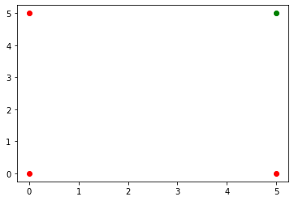

```python
perceptron.plotting(data,targetAnd)
```

```python
weight=perceptron.perceptronLearning(data,targetAnd)
```

[output not shown]

[output cut: 197 more lines]

[output not shown]

```python
print(weight[:,40])
```

```
[-2.7  1.2  2.4]
```

```python
#testing

for i in range(4):
    nilai=perceptron.activationValue(data[i,:],weight[:,40])
    print(nilai)
```

```
1
0
0
0
```

```
41
```

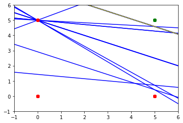

```python
#visualisation
perceptron.detFunction(weight,'b')
```

### Exercise

build a model using perceptron of logical data XOR

| X1 | X2 | Y |
| --- | --- | --- |
| 1 | 1 | 0 |
| 1 | 0 | 1 |
| 0 | 1 | 1 |
| 0 | 0 | 0 |